# Проверка статистических гипотез

Морские моллюски: набор данных Abalone

Автор

Черкасова Полина

## Требования к сдаче и оформлению задания

Заполните этот qmd-файл кодом и ответами. Порядок сдачи задания описан в README.md, в Google Classroom или на Stepik.

1. Старайтесь соблюдать единый стиль оформления и структуру отчёта. Не оставляйте лишние чанки кода, текст или комментарии, которые не относятся к решению задания.
2. Численные результаты представляйте в тексте или аккуратных таблицах с понятными подписями. Не оставляйте необработанный консольный вывод или отдельные числа без пояснений.
3. Графики должны быть достаточно крупными, с читаемыми русскими подписями, содержательным заголовком и правильно названными осями. Не используйте фон ggplot2 по умолчанию.
4. Ответы на вопросы и интерпретации результатов, включая графики, пишите обычным текстом, а не комментариями к коду. Код и его вывод не заменяют ответ на вопрос.
5. Сохраняйте исходную структуру проекта в репозитории. Не добавляйте лишние файлы, которые не относятся к проекту или выполнению заданий.
6. Оформление коммитов и веток на GitHub должно соответствовать общим правилам для всех курсов Института биоинформатики.

## О задании

- В этом домашнем задании мы будем использовать набор данных **Abalone**, содержащий измерения 4177 морских моллюсков рода *Haliotis*: [Подробнее](https://archive.ics.uci.edu/dataset/1/abalone).
- Вам предстоит проверить три статистические гипотезы: **две – с помощью доверительных интервалов (ДИ), одну – с помощью сравнения тестовой статистики с критическим значением**.
- Во всех заданиях используйте **уровень значимости $\alpha = 0.05$**. Для построения ДИ используйте **95%-й уровень доверия**.
- **Формулируйте выводы в терминах нулевой гипотезы**: мы отклоняем или не отклоняем именно её!

## О данных

Файл `abalone.csv` в директории `data` содержит несколько столбцов-признаков, из которых нам потребуются:

- **`Sex`**: `M` – самцы, `F` – самки, `I` – незрелые особи.
- **`Length`** – длина раковины, мм
- **`Shucked_weight`** – масса съедобной части моллюска после извлечения из раковины, г
- **`Shell_weight`** – масса высушенной раковины, г

## Загрузка и подготовка данных

Загрузите данные и оцените, требуется ли подготовка данных для анализа. Все ли признаки нужного типа?

```r
abalone_data <- read_csv("data/abalone.csv")
head(abalone_data,25)
```

```
# A tibble: 25 × 9
   Sex   Length Diameter Height Whole_weight Shucked_weight Viscera_weight
   <chr>  <dbl>    <dbl>  <dbl>        <dbl>          <dbl>          <dbl>
 1 M         91       73     19        103.            44.9           20.2
 2 M         70       53     18         45.1           19.9            9.7
 3 F        106       84     27        135.            51.3           28.3
 4 M         88       73     25        103.            43.1           22.8
 5 I         66       51     16         41             17.9            7.9
 6 I         85       60     19         70.3           28.2           15.5
 7 F        106       83     30        156.            47.4           28.3
 8 F        109       85     25        154.            58.8           29.9
 9 M         95       74     25        102.            43.3           22.5
10 F        110       88     30        179.            62.9           30.2
# ℹ 15 more rows
# ℹ 2 more variables: Shell_weight <dbl>, Rings <dbl>
```

## 1. Сравнение длины раковины самцов и самок

Исследователи хотят сравнить длину раковины самцов и самок. Вопрос исследования: **различается ли средняя длина раковины в популяциях самцов и самок?**

### Задание 1.1

Сформулируйте нулевую и альтернативную гипотезы. Какой параметр генеральной совокупности вы оцениваете?

Для ответа на вопрос исследователей необходимо сравнить разность средних длин раковины (колонка Length) между самками и самцами. Так как помимо самцов и самок в выборке присутсвуют неполовозрелые особи, то их стоит исключить из анализа.

- $H_0$: Средняя длина раковины в популяциях самцов и самок не различаются.
- $H_a$: Средняя длина раковины в популяциях самцов и самок различаются.

### Задание 1.2

Выберите и рассчитайте описательные статистики, необходимые для исследования вопроса.

Визуализируйте распределения исследуемого признака у самцов и самок. Кратко опишите особенности распределений. Предположите по графикам, различается ли средняя длина раковины между сравниваемыми группами.

```r
abalone_mf <- abalone_data %>%
  filter(Sex %in% c("M", "F")) %>%
  mutate(
    Sex = factor(Sex,
                 levels = c("F", "M"),
                 labels = c("Самки", "Самцы"))
  )

desc_length <- abalone_mf %>%
  select(Sex, Length) %>%
  tbl_summary(
    by = Sex,
    type = list(Length = "continuous2"),
    statistic = list(Length = c(
      "{mean} ({sd})",
      "{median} [{p25}, {p75}]",
      "{min}, {max}",
      "N = {N_nonmiss}"
    )),
    digits = list(Length = list(c(2, 2), c(2, 2, 2), c(0, 0), 0)),
    label = list(Length = "Длина раковины, мм")
  ) %>%
  modify_header(stat_1 = "**Самки**", stat_2 = "**Самцы**") %>%
  modify_caption("**Таблица 1.** Описательные статистики для длины раковины и пола") %>%
  bold_labels() %>%
  as_gt() %>%
  tab_style(style = cell_fill(color = "#E8F4F8"), locations = cells_column_labels())

desc_length
```

**Таблица 1.** Описательные статистики для длины раковины и пола

| **Characteristic** | **Самки** | **Самцы** |
| --- | --- | --- |
| Длина раковины, мм |  |  |
| Mean (SD) | 115.82 (17.23) | 112.28 (20.54) |
| Median [Q1, Q3] | 118 [105, 128.00] | 116 [101, 126.00] |
| Min, Max | 55.00, 163 | 31.00, 156 |
| N = N Non-missing | N = 1,307 | N = 1,528 |

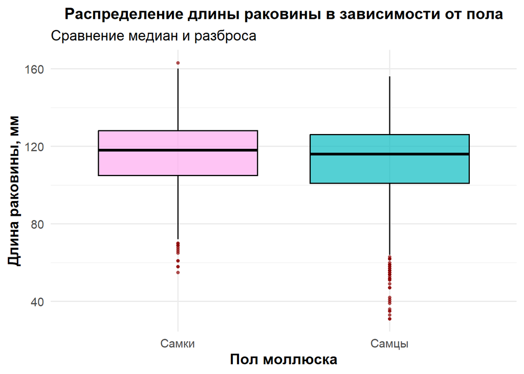

```r
p_length <- ggplot(abalone_mf, aes(x = Sex, y = Length, fill = Sex)) +
  geom_boxplot(alpha = 0.7, color = "black", outlier.color = "darkred",
               outlier.shape = 16, outlier.size = 1.2) +
  scale_fill_manual(values = c("Самки" = "#feabefb0", "Самцы" = "#0abbc194")) +
  labs(
    title = "Распределение длины раковины в зависимости от пола",
    subtitle = "Сравнение медиан и разброса",
    x = "Пол моллюска",
    y = "Длина раковины, мм"
  ) +
  theme_minimal(base_size = 14) +
  theme(
    legend.position = "none",
    plot.title = element_text(face = "bold", hjust = 0.5, size = 15),
    axis.title = element_text(face = "bold")
  )

p_length
```

### Задание 1.3

Выберите подходящий тип доверительного интервала и объясните, почему он соответствует исследовательскому вопросу.

Подходит двусторонний 95% доверительный интервал для разности средних двух независимых выборок, построенный по t-распределению, так как у нас большая выборка, а согласно ЦПТ любое распределение средних, при достаточной выборке, стремится к нормальному.

### Задание 1.4

Постройте выбранный доверительный интервал для проверки поставленной гипотезы

```r
ci_length <- t.test(
  Length ~ Sex,
  data = abalone_mf,
  alternative = "two.sided",
  conf.level = 0.95
)

ci_length_tbl <- tibble(
  "Среднее F (x̄_F)" = round(ci_length$estimate[1], 3),
  "Среднее M (x̄_M)" = round(ci_length$estimate[2], 3),
  "Разность (F − M)" = round(ci_length$estimate[1] - ci_length$estimate[2], 3),
  "95% ДИ нижняя" = round(ci_length$conf.int[1], 3),
  "95% ДИ верхняя" = round(ci_length$conf.int[2], 3),
  "t-статистика" = round(ci_length$statistic, 3),
  "p-значение" = signif(ci_length$p.value, 4)
) %>%
  gt() %>%
  tab_header(title = "Результаты t-теста для длины раковины") %>%
  cols_label(
    `Среднее F (x̄_F)` = "x̄_F", `Среднее M (x̄_M)` = "x̄_M",
    `Разность (F − M)` = "x̄_F − x̄_M", `95% ДИ нижняя` = "Нижняя граница",
    `95% ДИ верхняя` = "Верхняя граница"
  ) %>%
  tab_style(style = cell_fill(color = "#E8F4F8"), locations = cells_column_labels()) %>%
  fmt_number(columns = 1:6, decimals = 3) %>%
  fmt_number(columns = 7, decimals = 4)

ci_length_tbl
```

Результаты t-теста для длины раковины

| x̄_F | x̄_M | x̄_F − x̄_M | Нижняя граница | Верхняя граница | t-статистика | p-значение |
| --- | --- | --- | --- | --- | --- | --- |
| 115.819 | 112.278 | 3.541 | 2.149 | 4.932 | 4.991 | 0.0000 |

### Задание 1.5

На основании доверительного интервала проверьте сформулированную гипотезу. Объясните результат и решение.

Поскольку 95% доверительный интервал для разности средних “не захватывает” ноль (обе границы положительны), то мы отклоняем **Н0**

Что можно сказать о направлении и величине различия? Совпадает ли результат с вашим впечатлением от графика в задании 1.2? Как вы думаете, почему?

## 2. Сравнение массы съедобной части моллюска у самцов и самок

Исследователи предположили, что средняя масса съедобной части моллюска у самцов **больше**, чем у самок. Проверьте это предположение.

### Задание 2.1

Укажите, какой параметр генеральной совокупности вы оцениваете. Сформулируйте нулевую и альтернативную гипотезы.

> Обратите внимание на порядок вычитания средних: он определяет знак разности и её интерпретацию.

Необходимо оценить разность средних масс съедобной части между самцами и самками.

- $H_0$: Средняя масса съедобной части у самцов и самок одинакова.
- $H_a$: Средняя масса съедобной части у самцов больше, чем у самок.

### Задание 2.2

Выберите и рассчитайте описательные статистики, необходимые для исследования вопроса.

Визуализируйте распределения исследуемого признака у самцов и самок. Кратко опишите особенности распределений. Предположите по графикам, больше ли средняя масса съедобной части моллюска у самцов, чем у самок.

```r
desc_shucked <- abalone_mf %>%
  select(Sex, Shucked_weight) %>%
  tbl_summary(
    by = Sex,
    type = list(Shucked_weight = "continuous2"),
    statistic = list(Shucked_weight = c("{mean} ({sd})", "{median} [{p25}, {p75}]")),
    digits = list(Shucked_weight = list(c(3, 3), c(3, 3, 3))),
    label = list(Shucked_weight = "Масса съедобной части, г")
  ) %>%
  modify_header(stat_1 = "**Самки**", stat_2 = "**Самцы**") %>%
  modify_caption("**Таблица 2.** Описательные статистики массы съедобной части") %>%
  bold_labels() %>%
  as_gt() %>%
  tab_style(style = cell_fill(color = "#E8F4F8"), locations = cells_column_labels())

desc_shucked
```

**Таблица 2.** Описательные статистики массы съедобной части

| **Characteristic** | **Самки** | **Самцы** |
| --- | --- | --- |
| Масса съедобной части, г |  |  |
| Mean (SD) | 89.238 (39.733) | 86.589 (44.600) |
| Median [Q1, Q3] | 88.100 [59.000, 114.700] | 84.350 [55.250, 113.200] |

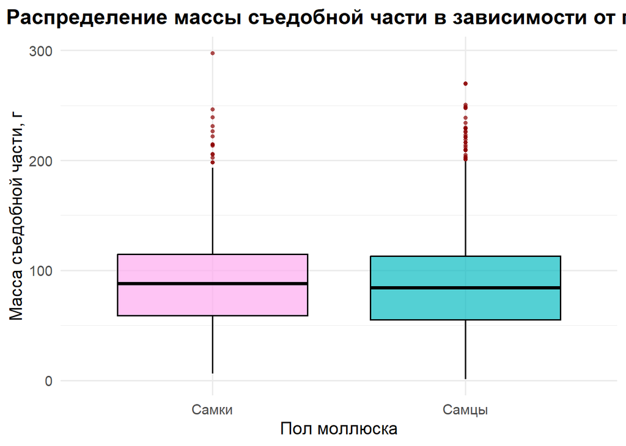

```r
p_shucked <- ggplot(abalone_mf, aes(x = Sex, y = Shucked_weight, fill = Sex)) +
  geom_boxplot(alpha = 0.7, color = "black", outlier.color = "darkred",
               outlier.shape = 16, outlier.size = 1.2) +
  scale_fill_manual(values = c("Самки" = "#feabefb0", "Самцы" = "#0abbc194")) +
  labs(
    title = "Распределение массы съедобной части в зависимости от пола",
    x = "Пол моллюска",
    y = "Масса съедобной части, г"
  ) +
  theme_minimal(base_size = 14) +
  theme(legend.position = "none", plot.title = element_text(face = "bold", hjust = 0.5))

p_shucked
```

Распредление симметричное, медианы находятся по центру “ящика”, разброс схож. Различий в размере съедобной части почти нет, но у самок она немного больше, чем у самцов. Значения выборок и форма распределений визуально почти не различаются.

### Задание 2.3

Выберите подходящий тип доверительного интервала и объясните, почему он соответствует исследовательскому вопросу.

Подойдет как двухсторонний доверительеый интервал, так и односторонний, потому как в данном случае нас интересует только одна “крайность” вопроса, а именно, что средняя масса съедобной части моллюска у самцов **больше**, чем у самок.

### Задание 2.4

Постройте выбранный доверительный интервал для проверки поставленной гипотезы

```r
abalone_mf_M_first <- abalone_mf %>%
  mutate(Sex = relevel(Sex, ref = "Самцы"))

ci_shucked <- t.test(
  Shucked_weight ~ Sex,
  data = abalone_mf_M_first,
  alternative = "greater",
  conf.level = 0.95
)

ci_shucked_tbl <- tibble(
  "Среднее M (x̄_M)" = round(ci_shucked$estimate[1], 3),
  "Среднее F (x̄_F)" = round(ci_shucked$estimate[2], 3),
  "Разность (M − F)" = round(ci_shucked$estimate[1] - ci_shucked$estimate[2], 3),
  "95% ДИ нижняя" = round(ci_shucked$conf.int[1], 3),
  "95% ДИ верхняя" = "+∞",
  "p-значение" = signif(ci_shucked$p.value, 4)
) %>%
  gt() %>%
  tab_header(title = "Результаты одностороннего t-теста для массы съедобной части") %>%
  tab_style(style = cell_fill(color = "#E8F4F8"), locations = cells_column_labels()) %>%
  fmt_number(columns = 1:4, decimals = 3) %>%
  fmt_number(columns = 6, decimals = 4)

ci_shucked_tbl
```

Результаты одностороннего t-теста для массы съедобной части

| Среднее M (x̄_M) | Среднее F (x̄_F) | Разность (M − F) | 95% ДИ нижняя | 95% ДИ верхняя | p-значение |
| --- | --- | --- | --- | --- | --- |
| 86.589 | 89.238 | −2.648 | −5.255 | +∞ | 0.9527 |

### Задание 2.5

На основании доверительного интервала проверьте сформулированную гипотезу. Поддерживают ли данные заявленное предположение?

Что можно сказать о направлении и величине различия? Совпадает ли результат с вашим впечатлением от графика в задании 2.2? Как вы думаете, почему?

Выборочная разность средних составила −2.648 г. Это означает, что в выборке самцы в среднем имели массу съедобной части на 2.6 г меньше, чем самки. На графике это тоже было заметно, но не настолько подробно.

## 3. Сравнение массы раковины незрелых особей и самок

Исследователи предположили, что средняя масса раковины *незрелых* особей **меньше**, чем у *самок*. Проверьте, поддерживают ли данные это предположение.

### Задание 3.1

Укажите, какой параметр генеральной совокупности вы оцениваете. Сформулируйте нулевую и альтернативную гипотезы.

Предпологается сравнение средних значений массы раковин незрелых особой и самок.

- $H_0$: Разницы в размере раковин между незрелыми особями и самками нет.
- $H_a$: Разница есть, средний размер ракковин самок больше, чем у незрелых особей.

### Задание 3.2

Выберите и рассчитайте описательные статистики, необходимые для исследования этого вопроса.

Визуализируйте распределения исследуемого признака у незрелых особей и самок. Кратко опишите особенности распределений. Предположите по графикам, меньше ли средняя масса раковины у незрелых особей, чем у самок.

```r
abalone_if <- abalone_data %>%
  filter(Sex %in% c("I", "F")) %>%
  mutate(
    Sex = factor(Sex,
                 levels = c("I", "F"),
                 labels = c("Незрелые (I)", "Самки (F)"))
  )

desc_shell <- abalone_if %>%
  select(Sex, Shell_weight) %>%
  tbl_summary(
    by = Sex,
    type = list(Shell_weight = "continuous2"),
    statistic = list(Shell_weight = c("{mean} ({sd})", "{median} [{p25}, {p75}]")),
    digits = list(Shell_weight = list(c(3, 3), c(3, 3, 3))),
    label = list(Shell_weight = "Масса раковины, г")
  ) %>%
  modify_header(stat_1 = "**Незрелые (I)**", stat_2 = "**Самки (F)**") %>%
  modify_caption("**Таблица 3.** Описательные статистики массы раковины") %>%
  bold_labels() %>%
  as_gt() %>%
  tab_style(style = cell_fill(color = "#E8F4F8"), locations = cells_column_labels())

desc_shell
```

**Таблица 3.** Описательные статистики массы раковины

| **Characteristic** | **Незрелые (I)** | **Самки (F)** |
| --- | --- | --- |
| Масса раковины, г |  |  |
| Mean (SD) | 25.636 (16.985) | 60.402 (25.130) |
| Median [Q1, Q3] | 22.600 [12.800, 35.700] | 59.000 [42.500, 75.000] |

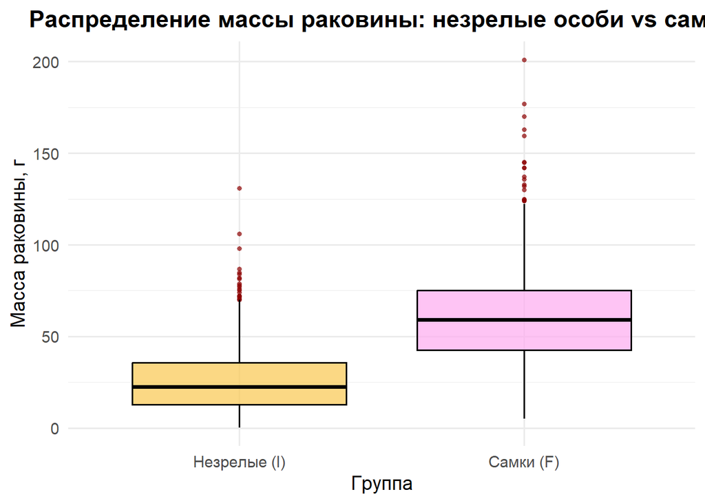

```r
p_shell <- ggplot(abalone_if, aes(x = Sex, y = Shell_weight, fill = Sex)) +
  geom_boxplot(alpha = 0.7, color = "black", outlier.color = "darkred",
               outlier.shape = 16, outlier.size = 1.2) +
  scale_fill_manual(values = c("Незрелые (I)" = "#f9c74f90", "Самки (F)" = "#feabefb0")) +
  labs(
    title = "Распределение массы раковины: незрелые особи vs самки",
    x = "Группа",
    y = "Масса раковины, г"
  ) +
  theme_minimal(base_size = 14) +
  theme(legend.position = "none", plot.title = element_text(face = "bold", hjust = 0.5))

p_shell
```

Визуально медиана и весь “ящик” у незрелых особей находятся значительно ниже, чем у самок. Можно уверенно сказать, что масса раковины у незрелых особей меньше.

### Задание 3.3

Выберите подходящий статистический критерий. Самостоятельно рассчитайте его наблюдаемую статистику и необходимые критические значения при заданном уровне значимости. Укажите критическую область.

Не используйте функции, выполняющие готовую проверку гипотез. Функции для вычисления квантилей распределений использовать можно. Вычислять p-значение в этом задании не нужно.

```r
stats_I <- abalone_if %>% filter(Sex == "Незрелые (I)") %>%
  summarise(n = n(), mean = mean(Shell_weight), sd = sd(Shell_weight))
stats_F <- abalone_if %>% filter(Sex == "Самки (F)") %>%
  summarise(n = n(), mean = mean(Shell_weight), sd = sd(Shell_weight))


# t = (x̄_I - x̄_F) / sqrt(s_I^2/n_I + s_F^2/n_F)
t_obs <- (stats_I$mean - stats_F$mean) / sqrt(stats_I$sd^2 / stats_I$n + stats_F$sd^2 / stats_F$n)

num <- (stats_I$sd^2 / stats_I$n + stats_F$sd^2 / stats_F$n)^2
denom <- (stats_I$sd^2 / stats_I$n)^2 / (stats_I$n - 1) + (stats_F$sd^2 / stats_F$n)^2 / (stats_F$n - 1)
df_welch <- num / denom

alpha <- 0.05
t_crit <- qt(alpha, df = df_welch)

t_results_tbl <- tibble(
  "Параметр" = c("Среднее (I)", "Среднее (F)", "Наблюдаемая t-статистика", "Степени свободы (df)", "Критическое значение (t_crit)"),
  "Значение" = c(round(stats_I$mean, 3), round(stats_F$mean, 3), round(t_obs, 3), round(df_welch, 1), round(t_crit, 3))
) %>%
  gt() %>%
  tab_header(title = "Ручной расчет статистик для Задания 3") %>%
  tab_style(style = cell_fill(color = "#E8F4F8"), locations = cells_column_labels())

t_results_tbl
```

Ручной расчет статистик для Задания 3

| Параметр | Значение |
| --- | --- |
| Среднее (I) | 25.636 |
| Среднее (F) | 60.402 |
| Наблюдаемая t-статистика | -41.608 |
| Степени свободы (df) | 2286.000 |
| Критическое значение (t_crit) | -1.646 |

Критическая область: так как альтернативная гипотеза левосторонняя,то и критическая область находится слева. Если наблюдаемая статистика попадает в эту область, то мы отклоняем нулевую гипотезу.

### Задание 3.4

На основании полученных результатов сформулируйте вывод относительно нулевой гипотезы и обоснуйте своё решение. Поддерживают ли данные предположение исследователей?

Что можно сказать о направлении и величине различия? Совпадает ли результат с вашим впечатлением от графика в задании 3.2? Как вы думаете, почему?

Наблюдаемая t-статистика значительно меньше критического значения (~ −1,645). Она попадает в левостороннюю критическую область. Следовательно, мы отклоняем нулевую гипотезу. Данные поддерживают предположение исследователей: средняя масса раковины незрелых особей статистически значимо меньше, чем у самок. Данный статистический вывод совпадает с визуальным впечатлением от графика, где медиана незрелых особей находится намного ниже. Большая разница в средних при огромном объёме выборки даёт очень высокое значение t-статистики по модулю, что делает результат высокозначимым. Так получилось из-за знамеателя знаменателя формулы t-статистики для двух независимых выборок, куда идет объём выборки. Чем больше объем, тем меньше дробь и, следовательно, весь знаменатель (стандартная ошибка) стремится к нулю.